# austin_palmer_hw6

Austin Palmer

2023-03-18

## 11.2

1. There is no indicator for Ford because the model must have a baseline to compare the other factors to.
2. $\beta_2$ can be interpreted as the scalar difference in car MPG between Ford and Subaru.
3. If car’s make is Ford then $\beta_1,\beta_2, \text{and} \beta_3$ would be zero, yielding $\mu = \beta_0$, implying that that the intercept, $\beta_0$, is a Ford car’s MPG.

## 11.3

$\mu$: tomato’s weight

$X_1$: Number of days growing

$X_2$: Type: Stripey or Roma

$\mu = \beta_0 + \beta_1X_1 + \beta_2X_2$

**a)**

- $\beta_0$: The initial weight of a tomato plant
- $\beta_1$: The average weight gain per day of growth
- $\beta_2$: The offset in weight between Roma and Mr. Stripey tomato plants

**b)** If $\beta_2$ were 0 then there is no difference in weight between Roma and Mr. Stripey tomato plants

## 11.4

$\mu = \beta_0 + \beta_1X_1 + \beta_2X_2 + \beta_3X_1X_2$

**a)** If $X_1$ and $X_2$ interact, then the rate of daily growth should be different for each type of plant

**b)** $\beta_3$ can be interpreted as the difference in growth rate between roma and Mr. Stripey tomato plants

## 11.10

**a)** body_mass_g ~ flipper_length + species

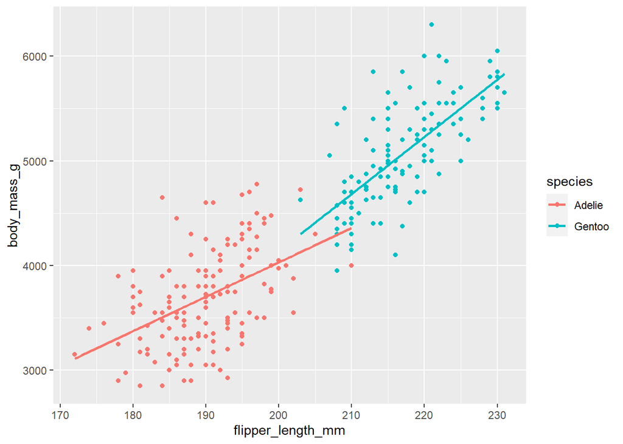

From examining the plot, both penguins exhibit a strong positive relationship between flipper length and body mass. Gentoo penguins have longer flippers and weight more on average than Adelie penguins. It seems the length to weight relationship for Gentoo might be slightly stronger than Adelie as well.

**b) Model**

Average penguin weights 3,500 - 4,500 grams

```r
b0<-normal(4000, 250)
b1<-normal(0,2.5,autoscale = TRUE)
sigma<-exponential(1,autoscale=TRUE)
penguin_model <-stan_glm(
  body_mass_g ~ flipper_length_mm + species, family=gaussian,
  data=penguin_data,
  prior_intercept = b0,
  prior=b1,
  prior_aux = sigma,
  chains=4, iter=5000*2, seed=84735
)
```

**c) MCMC Diagnostics**

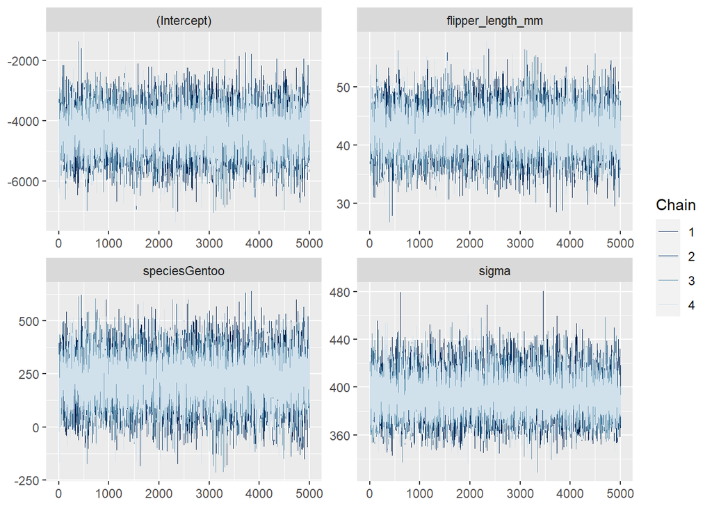

```r
mcmc_trace(penguin_model, size=0.1)
```

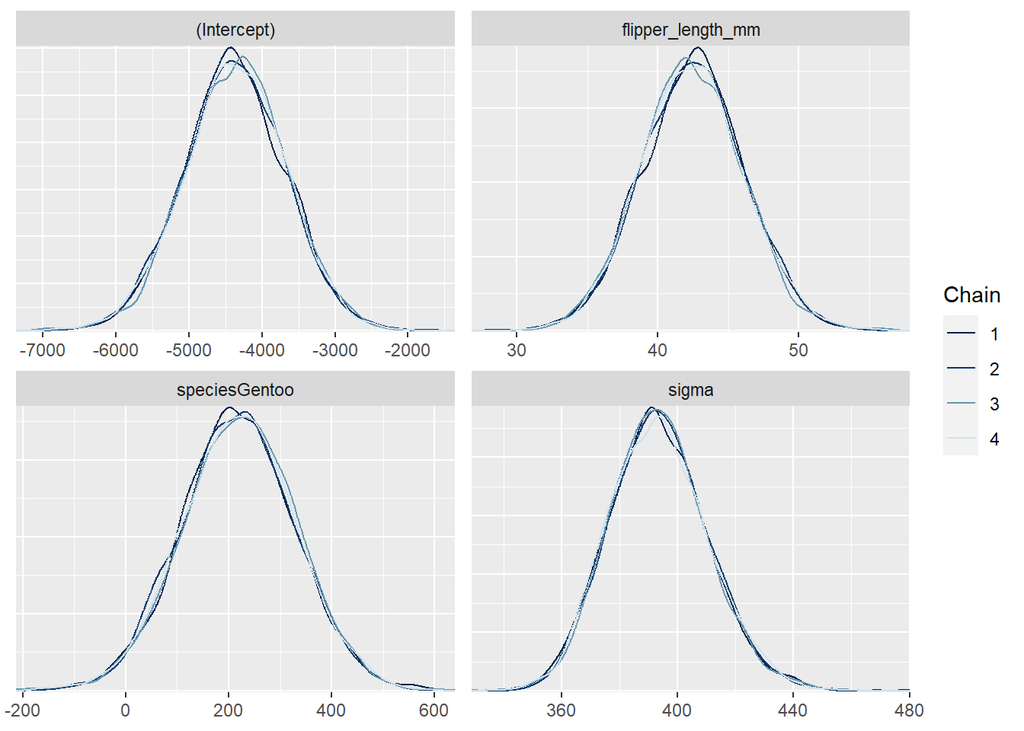

```r
mcmc_dens_overlay(penguin_model)
```

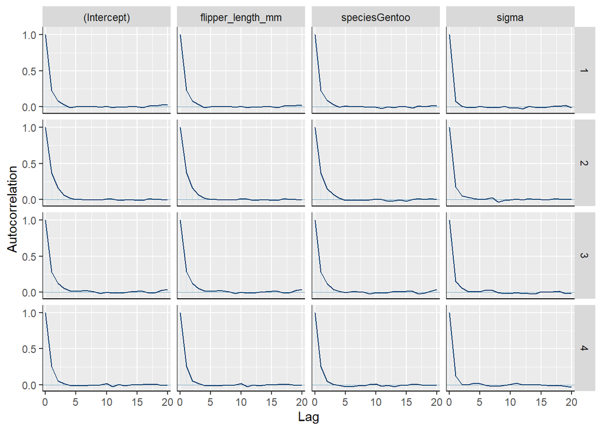

```r
mcmc_acf(penguin_model)
```

```r
posterior_interval(penguin_model, prob=0.80)
```

```
##                           10%         90%
## (Intercept)       -5262.29274 -3484.18777
## flipper_length_mm    37.81419    47.17034
## speciesGentoo        78.01531   360.56809
## sigma               372.18084   415.56136
```

**d) `tidy()` summary**

```r
tidy(penguin_model, effects = c("fixed", "aux"),
     conf.int = TRUE, conf.level = 0.80) %>%
  select(-std.error)
```

```
## # A tibble: 5 × 4
##   term              estimate conf.low conf.high
##   <chr>                <dbl>    <dbl>     <dbl>
## 1 (Intercept)        -4366.   -5262.    -3484.
## 2 flipper_length_mm     42.4     37.8      47.2
## 3 speciesGentoo        220.      78.0     361.
## 4 sigma                393.     372.      416.
## 5 mean_PPD            4315.    4272.     4358.
```

**e) Posterior Prediction** Flipper length = 197

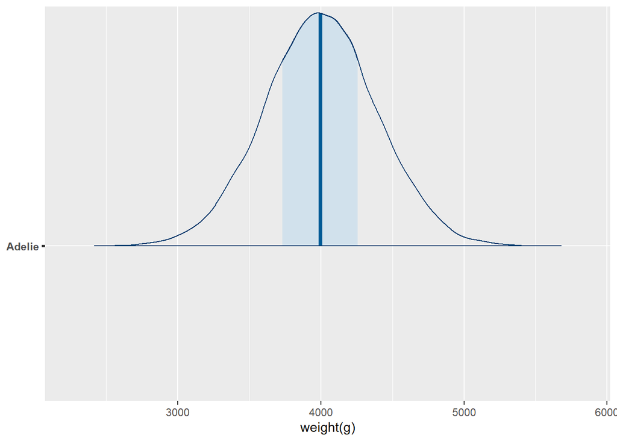

```r
weight_prediction <- posterior_predict(
  penguin_model,
  newdata = data.frame(flipper_length_mm=197,
                       species=c("Adelie"))
)

mcmc_areas(weight_prediction) +
  ggplot2::scale_y_discrete(labels = c("Adelie")) +
  xlab("weight(g)")
```

I find an Adelie penguin with 197mm flippers to weigh around 4000g with the range 3000-5000 plausible.

## 11.11

**a) posterior simulation**

Model: body_mass_g ~ flipper_length_mm + species + flipper_length_mm * species

```r
penguin_interaction_model <- stan_glm(
  body_mass_g ~ flipper_length_mm + species + flipper_length_mm*species,
  family = gaussian,
  data = penguin_data,
  prior_intercept = b0,
  prior = b1,
  prior_aux = sigma,
  chains=4,iter=5000*2
)
```

**b) posterior plausibilities plot**

```r
penguin_data %>%
  add_fitted_draws(penguin_interaction_model, n = 50) %>%
  ggplot(aes(x = flipper_length_mm, y = body_mass_g, color = species)) +
    geom_line(aes(y = .value, group = paste(species, .draw)), alpha = 0.1)
```

[output not shown]

**c)**

```r
tidy(penguin_interaction_model, effects = c("fixed", "aux"),
     conf.int = TRUE, conf.level = 0.80)
```

```
## # A tibble: 6 × 5
##   term                            estimate std.error conf.low conf.high
##   <chr>                              <dbl>     <dbl>    <dbl>     <dbl>
## 1 (Intercept)                      -2905.     881.   -4019.     -1785.
## 2 flipper_length_mm                   34.8      4.64    28.9       40.6
## 3 speciesGentoo                    -3321.    1314.   -5024.     -1638.
## 4 flipper_length_mm:speciesGentoo     17.2      6.39     9.09      25.5
## 5 sigma                              387.      16.9    367.       410.
## 6 mean_PPD                          4315.      33.4   4272.      4358.
```

## 11.12

**a) Model**

```r
penguin_model_3<-stan_glm(
  body_mass_g ~ flipper_length_mm + bill_length_mm + bill_depth_mm,
  family = gaussian,
  data = penguin_data,
  prior_intercept = b0,
  prior = b1,
  prior_aux = sigma,
  chains=4, iter=5000*2
)
```

```r
print(penguin_model_3)
```

```
## stan_glm
##  family:       gaussian [identity]
##  formula:      body_mass_g ~ flipper_length_mm + bill_length_mm + bill_depth_mm
##  observations: 274
##  predictors:   4
## ------
##                   Median  MAD_SD
## (Intercept)       -6146.9   549.4
## flipper_length_mm    32.2     3.0
## bill_length_mm       71.6     8.0
## bill_depth_mm        54.0    13.3
##
## Auxiliary parameter(s):
##       Median MAD_SD
## sigma 338.9   14.6
##
## ------
## * For help interpreting the printed output see ?print.stanreg
## * For info on the priors used see ?prior_summary.stanreg
```

**b) 95% Credible Interval**

```r
posterior_interval(penguin_model_3, .95)
```

```
##                          2.5%       97.5%
## (Intercept)       -7218.48422 -5077.60566
## flipper_length_mm    26.23088    38.00876
## bill_length_mm       55.77702    87.30710
## bill_depth_mm        28.28058    80.02464
## sigma               312.48134   370.19715
```

## 11.13

**a) Models simulation**

```r
model_1 <- stan_glm(
  body_mass_g~flipper_length_mm,
  family = gaussian, data = penguin_data,
  prior_intercept = b0,
  prior = b1,
  prior_aux = sigma
)

model_2 <- stan_glm(
  body_mass_g~species,
  family = gaussian, data = penguin_data,
  prior_intercept = b0,
  prior = b1,
  prior_aux = sigma
)

model_3 <- stan_glm(
  body_mass_g~flipper_length_mm + species,
  family = gaussian, data = penguin_data,
  prior_intercept = b0,
  prior = b1,
  prior_aux = sigma
)

model_4 <- stan_glm(
  body_mass_g~flipper_length_mm + bill_length_mm + bill_depth_mm,
  family = gaussian, data = penguin_data,
  prior_intercept = b0,
  prior = b1,
  prior_aux = sigma
)
```

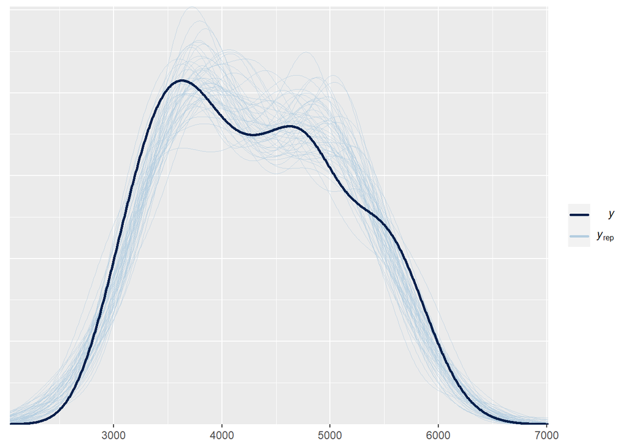

```r
pp_check(model_1)
```

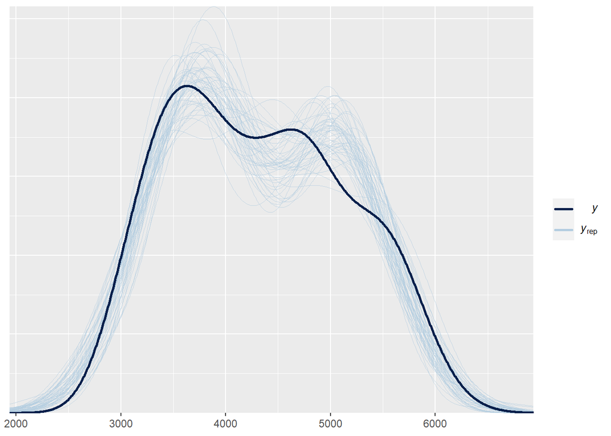

```r
pp_check(model_2)
```

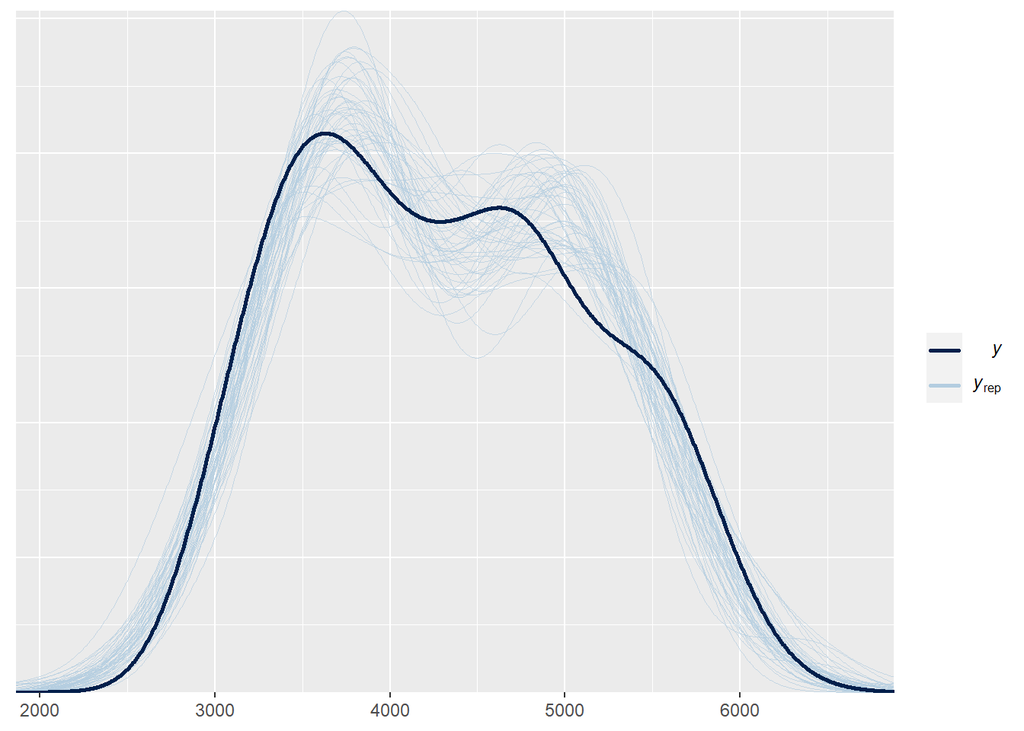

```r
pp_check(model_3)
```

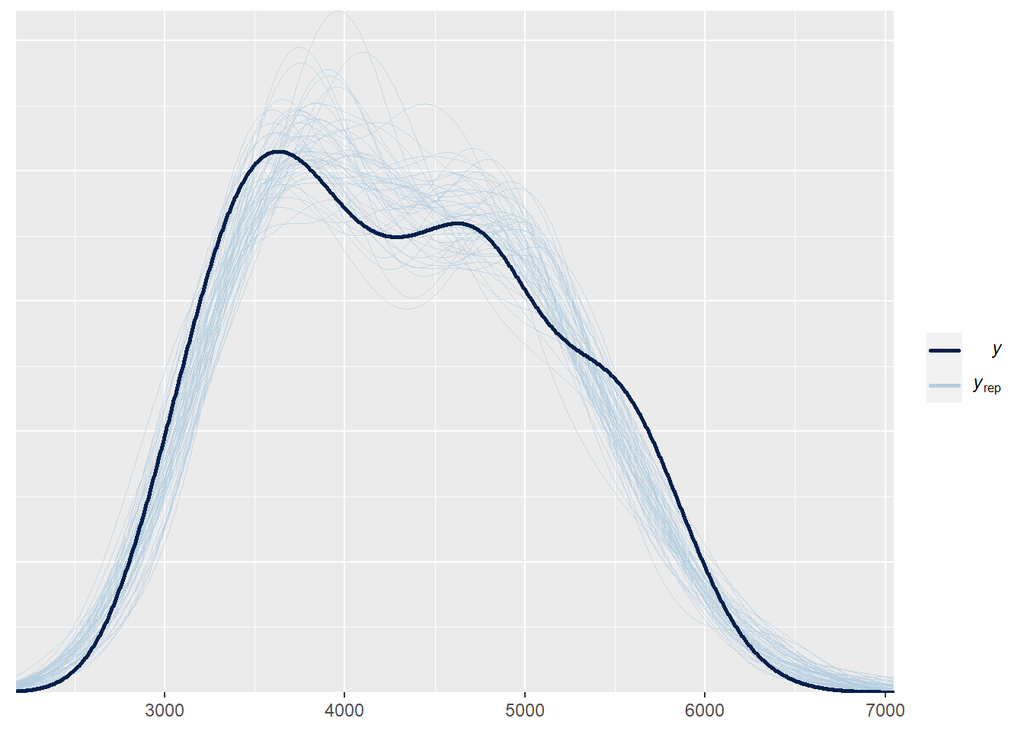

```r
pp_check(model_4)
```

The first model considering only flipper length does okay predicting weight, but is relatively unsure and has a wide spread around common weight values. The second model, which only considered species, over-predicts the bi-modalidty of the weight distribution and still has a wide spread. The third model, taking into account both flipper length and species, has a more concentrated spread of predictions around concentrated weights and sticks closer to the real data peaks than prior single explanatory models. The last model, which uses flipper length, bill length, bill depth, and ignores species, doesn’t seem to capture the peaks of the real data as well as when species was considered.

**c) 10-Fold Cross-Validation**

```r
val1 <- prediction_summary_cv(model=model_1, data=penguins_complete, k=10)
val2 <- prediction_summary_cv(model=model_2, data=penguins_complete, k=10)
val3 <- prediction_summary_cv(model=model_3, data=penguins_complete, k=10)
val4 <- prediction_summary_cv(model=model_4, data=penguins_complete, k=10)

modelValidation<- rbind(val1$cv,val2$cv,val3$cv,val4$cv)
modelValidation["Model Number"] <- c("Model 1", "Model 2", "Model 3", "Model 4")
print(modelValidation)
```

```
##        mae mae_scaled within_50 within_95 Model Number
## 1 259.5940  0.6590502 0.5156863 0.9459893      Model 1
## 2 328.4353  0.7084032 0.4772727 0.9551693      Model 2
## 3 255.9282  0.6765181 0.5049020 0.9491087      Model 3
## 4 273.4307  0.6919254 0.5077540 0.9487522      Model 4
```

**d) ELPD posterior predictive accuracy**

```r
loo_1 <- loo(model_1)
loo_2 <- loo(model_2)
loo_3 <- loo(model_3)
loo_4 <- loo(model_4)

loo_compare(loo_1, loo_2, loo_3, loo_4)
```

```
##         elpd_diff se_diff
## model_4   0.0       0.0
## model_3 -39.9       7.4
## model_1 -40.9       7.1
## model_2 -94.5      11.4
```

From an ELPD evaluation, model 4 is the best predictor by a significant margin. Models 1 and 3 are very similarly accurate, and as above, model 2 is the worst predictor.

## 11.14

**- bill_length ~ body_mass + sex**

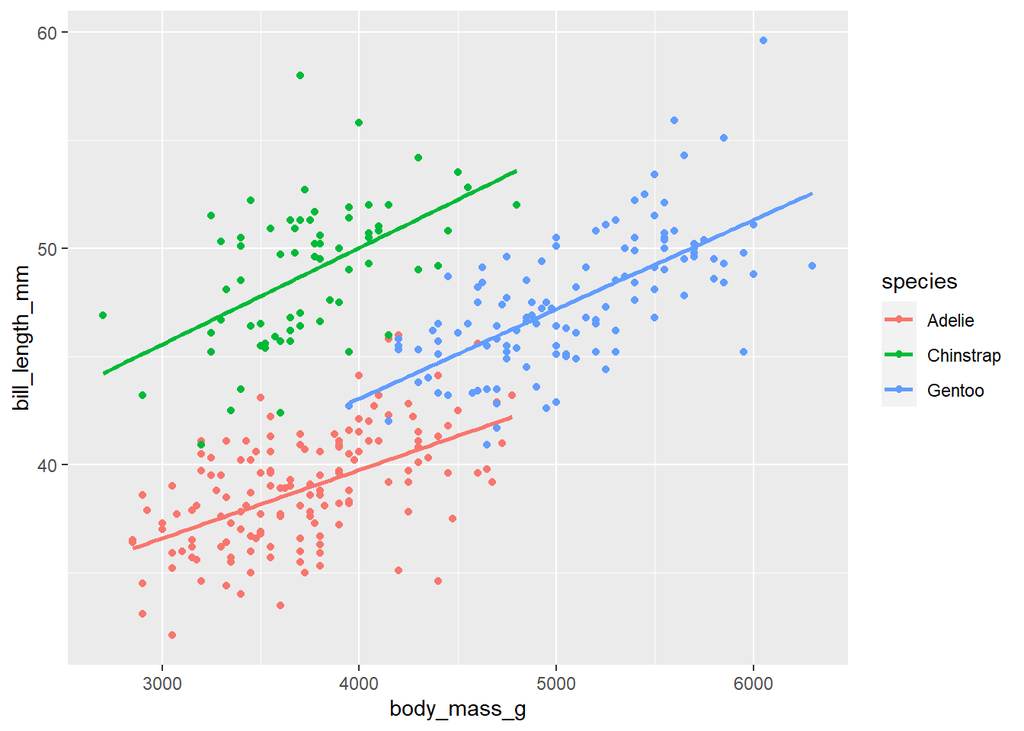

```r
ggplot(penguins_complete, aes(y = bill_length_mm, x = body_mass_g, color = species)) +
  geom_point() +
  geom_smooth(method = "lm", se = FALSE)
```

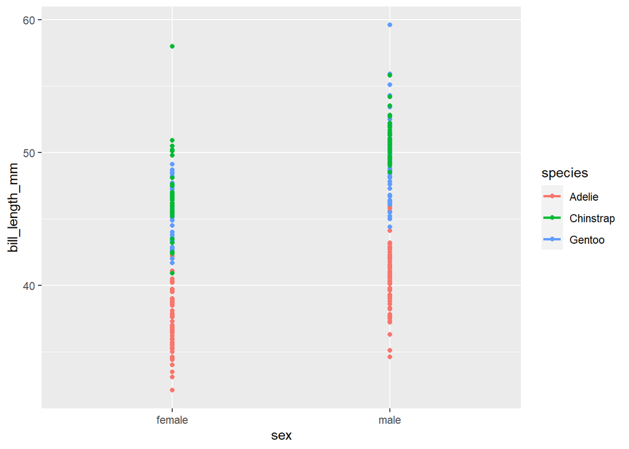

```r
ggplot(penguins_complete, aes(y = bill_length_mm, x = sex, color = species)) +
  geom_point() +
  geom_smooth(method = "lm", se = FALSE)
```

```r
sd(penguins_complete$bill_length_mm)
b0 <- normal(44.45, 5.46)

myModel1 <- stan_glm(
  bill_length_mm ~ body_mass_g + sex,
  family = gaussian,
  data = penguins_complete,
  prior_intercept = b0,
  prior = b1,
  prior_aux = sigma,
  chains=4,iter=5000*2
)
```

```r
print(myModel1)
```

```
## stan_glm
##  family:       gaussian [identity]
##  formula:      bill_length_mm ~ body_mass_g + sex
##  observations: 333
##  predictors:   3
## ------
##             Median MAD_SD
## (Intercept) 27.9    1.3
## body_mass_g  0.0    0.0
## sexmale      1.2    0.5
##
## Auxiliary parameter(s):
##       Median MAD_SD
## sigma 4.4    0.2
##
## ------
## * For help interpreting the printed output see ?print.stanreg
## * For info on the priors used see ?prior_summary.stanreg
```

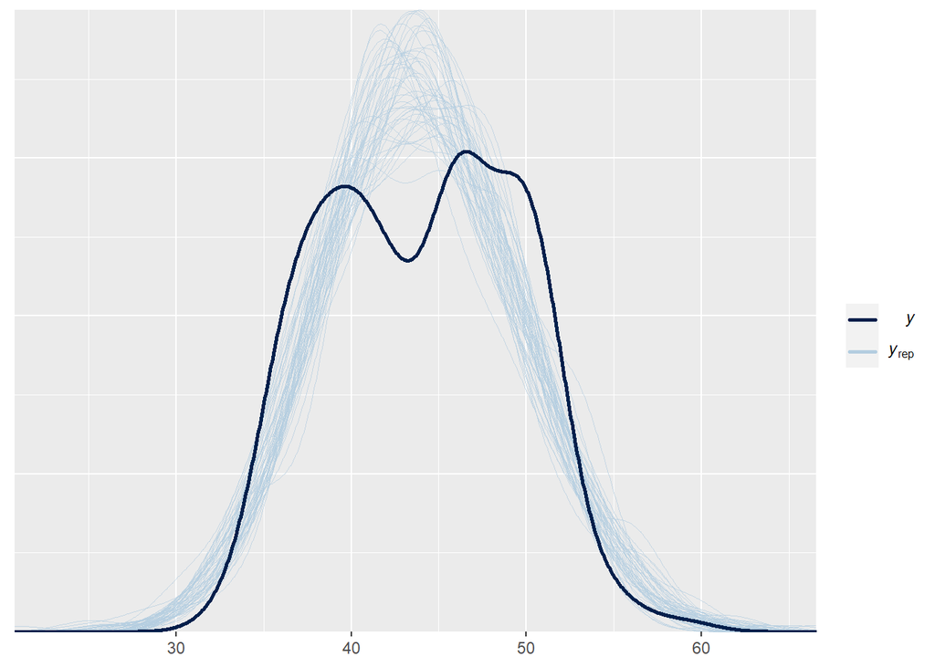

```r
pp_check(myModel1)
```

```r
prediction_summary_cv(model = myModel1, data = penguins_complete, k = 10)
```

```
## $folds
##    fold      mae mae_scaled within_50 within_95
## 1     1 3.233263  0.7283099 0.4411765 0.9705882
## 2     2 3.085867  0.6919773 0.4545455 0.9696970
## 3     3 3.234662  0.7315213 0.4545455 0.9393939
## 4     4 2.432522  0.5459913 0.5757576 0.9696970
## 5     5 2.025819  0.4475121 0.6176471 1.0000000
## 6     6 2.258774  0.5117936 0.5757576 0.9090909
## 7     7 3.517102  0.7985861 0.4545455 0.9696970
## 8     8 3.531640  0.7870566 0.4848485 0.9696970
## 9     9 2.837217  0.6515060 0.5151515 0.8484848
## 10   10 3.114923  0.7000536 0.5000000 0.9411765
##
## $cv
##        mae mae_scaled within_50 within_95
## 1 2.927179  0.6594308 0.5073975 0.9487522
```

For my first model, I used body mass and sex as explanitories. It seems sex has a weak positive relationship between males and longer bills. From the `pp_check` it seems the model isn’t capturing the data’s bi-modality. I think this is stemming from not accounting for species so the body mass and sex look far more random because each penguin species has different averages for each explanatory. Body mass is estimated to have no relivance, I will leave it in and account for species to see if some meaning is uncovered.

**- bill_length ~ body_mass + sex + species**

```r
myModel2 <- stan_glm(
  bill_length_mm ~ body_mass_g + sex + species,
  family = gaussian,
  data = penguins_complete,
  prior_intercept = b0,
  prior = b1,
  prior_aux = sigma,
  chains=4,iter=5000*2
)
```

```r
print(myModel2)
```

```
## stan_glm
##  family:       gaussian [identity]
##  formula:      bill_length_mm ~ body_mass_g + sex + species
##  observations: 333
##  predictors:   5
## ------
##                  Median MAD_SD
## (Intercept)      31.0    1.3
## body_mass_g       0.0    0.0
## sexmale           2.5    0.4
## speciesChinstrap 10.0    0.3
## speciesGentoo     6.3    0.6
##
## Auxiliary parameter(s):
##       Median MAD_SD
## sigma 2.3    0.1
##
## ------
## * For help interpreting the printed output see ?print.stanreg
## * For info on the priors used see ?prior_summary.stanreg
```

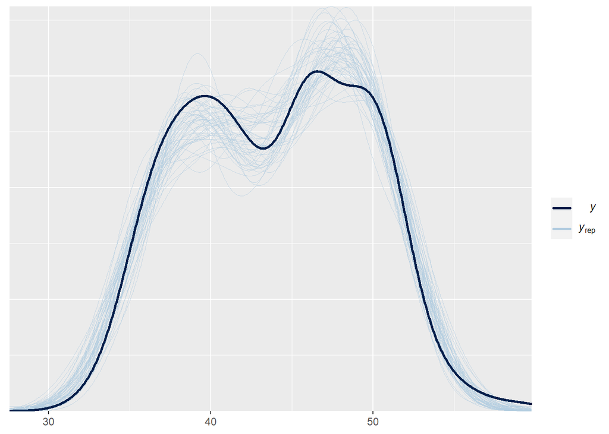

```r
pp_check(myModel2)
```

```r
prediction_summary_cv(model = myModel2, data = penguins_complete, k = 10)
```

```
## $folds
##    fold      mae mae_scaled within_50 within_95
## 1     1 1.364443  0.5844077 0.5882353 0.9705882
## 2     2 1.221623  0.5276854 0.6363636 0.9696970
## 3     3 1.470760  0.6259855 0.5757576 1.0000000
## 4     4 1.252043  0.5573455 0.5757576 0.9393939
## 5     5 0.954852  0.4100771 0.6470588 1.0000000
## 6     6 1.464922  0.6604436 0.5151515 0.8484848
## 7     7 1.393455  0.6192975 0.5454545 0.9090909
## 8     8 1.277025  0.5642153 0.5757576 0.8787879
## 9     9 1.578219  0.6876570 0.4848485 0.9393939
## 10   10 1.726464  0.7546733 0.4411765 1.0000000
##
## $cv
##        mae mae_scaled within_50 within_95
## 1 1.370381  0.5991788 0.5585561 0.9455437
```

Accounting for species very significantly improves my model. The relationship between sex and bill length is twice as impactful as compared to when it was muddled by mixed species. Visually, the predicted models are now able to capture the bi-modality of the data much better, but the first peak seems to be underestimated, and the second overestimated. Numerically the `mae` halfed but `mae_scaled` barely budged. The `within_50` interval is significantly higher but `within_95` didn’t change much, suggesting that the prediction spread decreased significantly by considering species. Body mass is still irrelevant so for the next iteration I will replace that with a different explanitory.

**-bill_length ~ bill_depth + year + island + sex + species**

```r
myModel3 <- stan_glm(
  bill_length_mm ~ bill_depth_mm + year + sex + species + island + bill_depth_mm*sex,
  family = gaussian,
  data = penguins_complete,
  prior_intercept = b0,
  prior = b1,
  prior_aux = sigma,
  chains=4,iter=5000*2
)
```

```r
print(myModel3)
```

```
## stan_glm
##  family:       gaussian [identity]
##  formula:      bill_length_mm ~ bill_depth_mm + year + sex + species + island +
##     bill_depth_mm * sex
##  observations: 333
##  predictors:   9
## ------
##                       Median MAD_SD
## (Intercept)           -702.9  312.6
## bill_depth_mm            0.6    0.2
## year                     0.4    0.2
## sexmale                  5.5    2.3
## speciesChinstrap        10.3    0.4
## speciesGentoo           10.4    0.7
## islandDream             -0.4    0.5
## islandTorgersen          0.1    0.5
## bill_depth_mm:sexmale   -0.2    0.1
##
## Auxiliary parameter(s):
##       Median MAD_SD
## sigma 2.3    0.1
##
## ------
## * For help interpreting the printed output see ?print.stanreg
## * For info on the priors used see ?prior_summary.stanreg
```

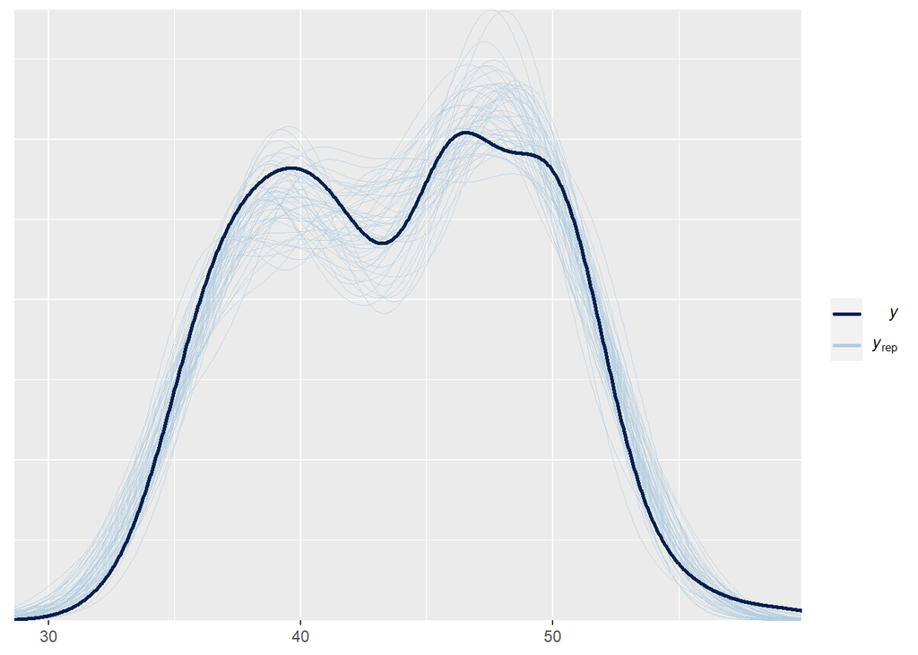

```r
pp_check(myModel3)
```

```r
prediction_summary_cv(model = myModel3, data = penguins_complete, k = 10)
```

```
## $folds
##    fold      mae mae_scaled within_50 within_95
## 1     1 1.329931  0.5633297 0.6470588 0.9705882
## 2     2 1.081007  0.4559444 0.6969697 0.9696970
## 3     3 1.505058  0.6455024 0.5151515 0.9393939
## 4     4 1.003306  0.4338329 0.5454545 1.0000000
## 5     5 1.543946  0.6819849 0.5000000 0.9705882
## 6     6 1.266546  0.5464289 0.6666667 0.9393939
## 7     7 1.034522  0.4392695 0.7272727 1.0000000
## 8     8 1.200514  0.5374989 0.5757576 0.8787879
## 9     9 1.579013  0.6921773 0.4848485 0.9090909
## 10   10 1.448183  0.6267634 0.5588235 0.9117647
##
## $cv
##        mae mae_scaled within_50 within_95
## 1 1.299202  0.5622732 0.5918004 0.9489305
```